# 20231023_metricSims

2023-11-01

Needs a fair bit of re-working.

## Metric evaluation

These plots are meant to be follow-up plots to anything interesting from the caterpillars above. For example, if we see that a specific model of missingness leads to an odd-looking effect on the caterpillar plots (i.e., affect the re-estimations in a systematic way), then we can look into its specific metric changes when we change the missingness model.

This missingness model will be changed in terms of both which parameters are in it and what the parameter values are (e.g., higher or lower gwesp/altstar values). These don’t need to be re-estimations of anything really, these would just be different ways of degrading the ‘full’ network given a specific missingness proportion. From then on, we can then suggest that specific parameter values and specific parameters lead to some effects.

Some of the metrics we can look at include clustering and centralisation and some of the mean value parameterisations obtained from not estimating each parameter (obtainable through summary(model)).

These metrics will not require re-estimations, but should be guided BY the re-estimations because there are a lot of metrics and possible parameter values and specifications.

What will actually be done here is given a depleted network, as guided by the caterpillar plots above, we can first calculate the various metrics the depleted networks have, a ‘benchmark’ from the ‘true’ network, and simulations given the depleted network… right?

```r
# function to calculate metrics
netMetrics = function(net, directed = FALSE){

  ## netMetrics(net, directed) calculates some metrics for a given network. Needs the 'sna' package
  ## and the 'network' package to work.
  ##
  ## Input:
  ## - net: Ideally a network object for the network whose metrics will be calculated. Technically
  ##        can be an adjacency matrix since it will be converted to a network object.
  ##
  ## - directed: A logical value to indicate whether the network is directed or not.
  ##
  ## Output:
  ## - The output is a list of different network metrics. These include the clustering coefficient,
  ##   the global centralisation (degree variance) value, the median geodesic distance, and median
  ##   betweenness centrality. More metrics can be added on as necessary.

  # needs two packages
  require(network)
  require(sna)

  # specify if undirected or not
  mode = 'graph'

  # if instead directed network are the input, turn it directed
  if(directed == TRUE){
    mode = 'digraph'
  }

  # if input is an adjacency matrix, turn it into a network object
  if(inherits(net, "matrix")){
    net = as.network(net, directed = directed)
    print("Matrix coerced to network object")

  }

  # make sure there's no missingness in it
  if(network.naedgecount(net) != 0){

    tempMat = as.matrix(net)
    tempMat[is.na(tempMat)] = 0
    net = as.network(tempMat, directed = directed)
    print("Missing values in the network converted to 0s")

  }



  # getting a distribution of clustering coefficients for the 80 simulated graphs
  tempClust <- gtrans(net, mode = mode)
  tempCent <- centralization(net, degree, mode = mode)
  tempGeodistMedian <- median(geodist(net, inf.replace = NA)$gdist, na.rm = T)
  tempBetwMedian <- median(betweenness(net, gmode = mode))

  ## specify the chosen metric
  metricList = list("clustering" = tempClust,
                    "centralisation" = tempCent,
                    "MedianGeodesic" = tempGeodistMedian,
                    "MedianBetween" = tempBetwMedian)

  # return the list of metrics
  return(metricList)

}


## get mean value parameterisations
# function to check mean value parameterisations
meanValPar = function(net, model){

  ## net is the outcome network, usually the degraded adjacency matrix
  ## model is a STRING for the specified model

  # paste together the input network object and the specified model
  eval(parse(text = paste("chosenModel = net", "~", model )))

  # check mean value par
  summary(chosenModel)
}

# this list can then be used to plot stuff
geneSimNets = function(net, modelSpec, initParas, chosenPara, paraRange, trueAdj){

  # takes a network, like a depleted network without missingness (i.e., saved as 0)
  # use different models to simulate networks with the same amount of edges
    # i.e., simulating the effects of various parameter values (and model specification)
    # on a depleted network with constrained edges/density
  # ideally accommodates a range of different model specifications and parameter values
  # the parameters are varied one at a time to view its effect holding constant on other parameters....
  # so the function will look like
  # simNet(toddNet, modelSpec, initParas, chosenPara, paraRange, trueAdj)
  # output = list of simulated networks,
  # mean value parameterisations can be applied in a separate chunk of code for the list
  # of simulated networks since it'd be conditional to the model specified for the simulated networks.

  ### NO:
  # take a simulated missingness matrix with a fixed proportion
  # specify some model, with varying specification or parameter values,
  # then simulate some other possible missingness matrices
  # while constraining the edges (fixed prportion of missingness)
  # use the simulated missingness matrices to deplete true adjmat X
  # then calculate metrics and mean value parameterisations on the depleted network

  ## checks
  # make sure it's a network object
  if(inherits(net, "matrix")){
    net = as.network(net)
  }

  # make sure there's no missingness in it
  if(network.naedgecount(testNet) != 0){
    stop("Network has missing values in it.")
  }

  # degree covariate calculation, should I retroactively update the reestimation code to attach the degree covariate...
  # might be better to specify the true network here...
  net %v% 'degree' = rowSums(trueAdj)

  # initialising the simulation
  netStart = net
  simNetList = list()

  # loop to simulate different gwdeg values
  for (paraIndex in c(1:length(paraRange)) ){

   # a conditional after the first loop for making the starting network iterate between gwdeg parameters
    if ( paraIndex > 1 ){
    netStart <- tempSimNets[[1]]
       netStart %v% 'degree' = rowSums(trueAdj)
    }

    # choose coefs
    chosenCoefs = initParas
    chosenCoefs[chosenPara] = paraRange[paraIndex]

    # simulating 80 networks given the specified model and their parameter values
    tempSimNets <- simulate(object = modelSpec,
                            constraints =~edges,
                            coef= chosenCoefs,
                            control=control.simulate(
                              MCMC.burnin=20000,
                              MCMC.interval=100), nsim=80 )

    # save the simulated networks
    simNetList[[paraIndex]] = tempSimNets

  }
  # return the simulated 'networks' (these are simulated missingness matrices saved as networks)
  return(simNetList)

}

# mean value parameterisation extraction... does this need to be a function?
# could just be a line of code... probably...
```

### Todd MVPs and metrics

```r
# reading some packages
library(sna)
library(ergm)
library(network)
library(here)
library(dplyr)
```

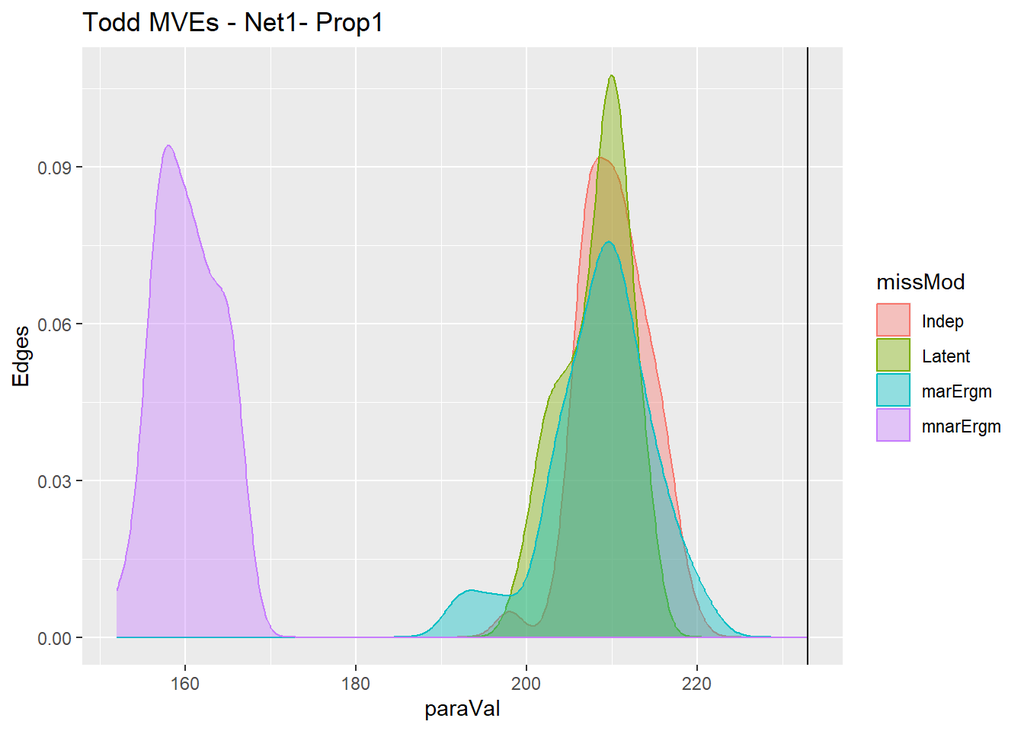

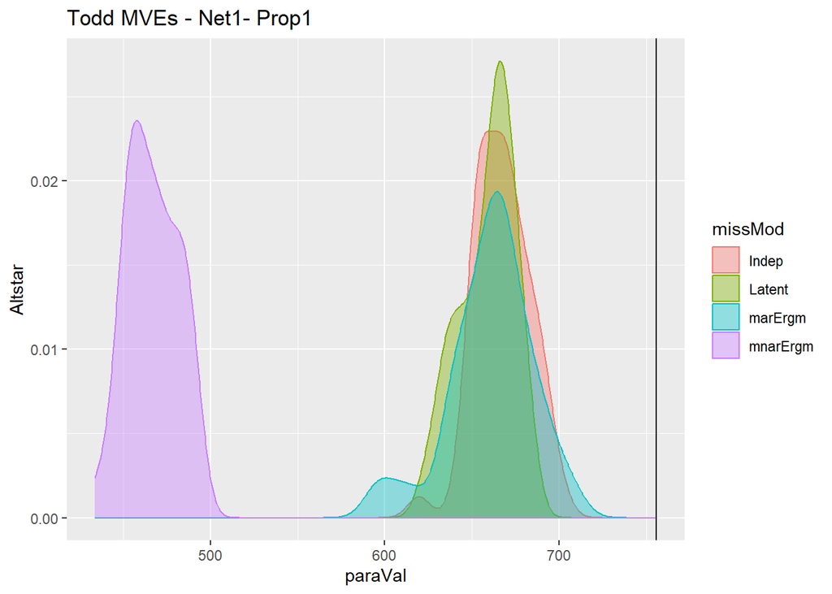

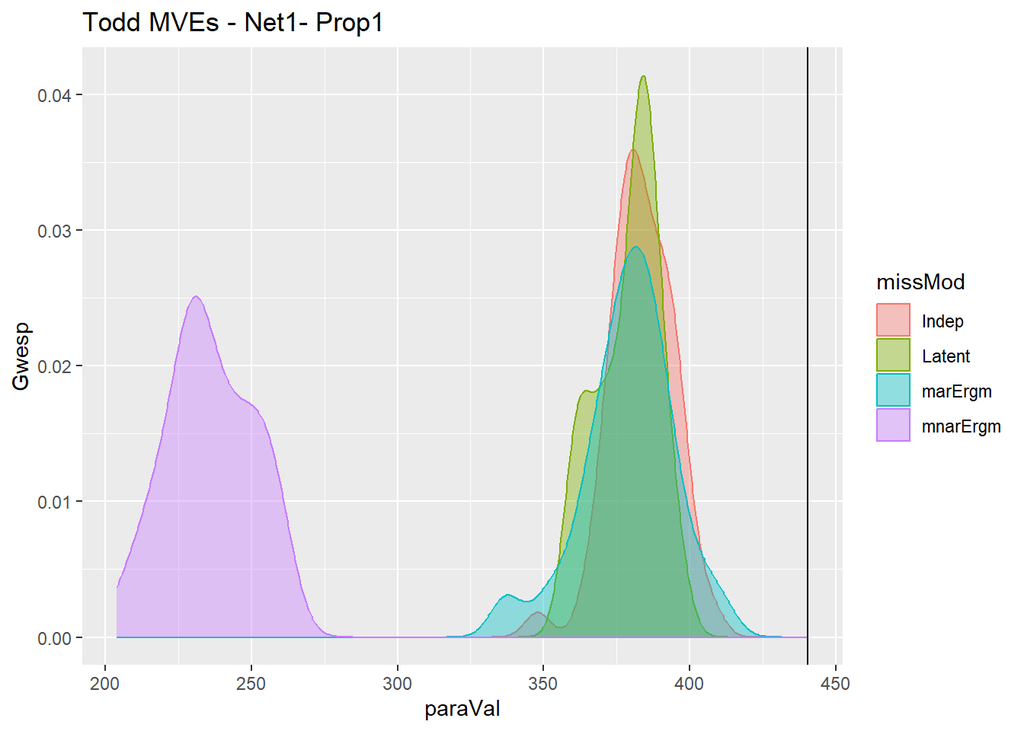

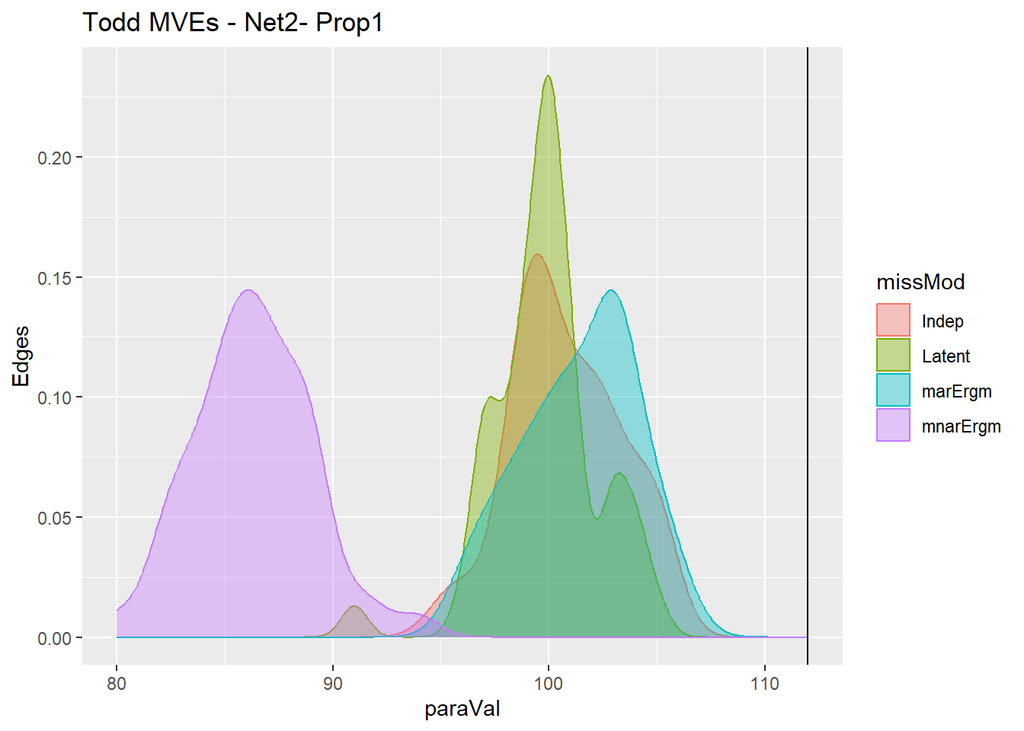

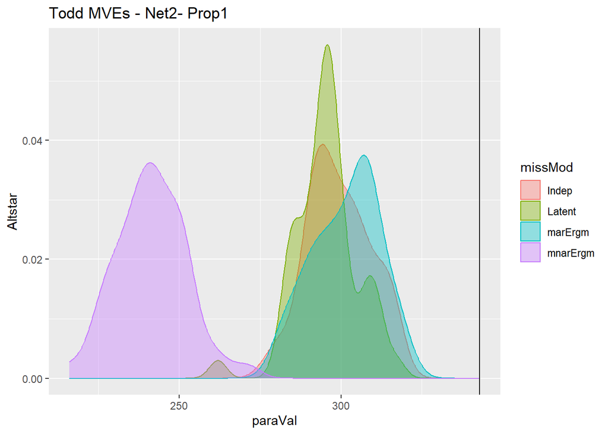

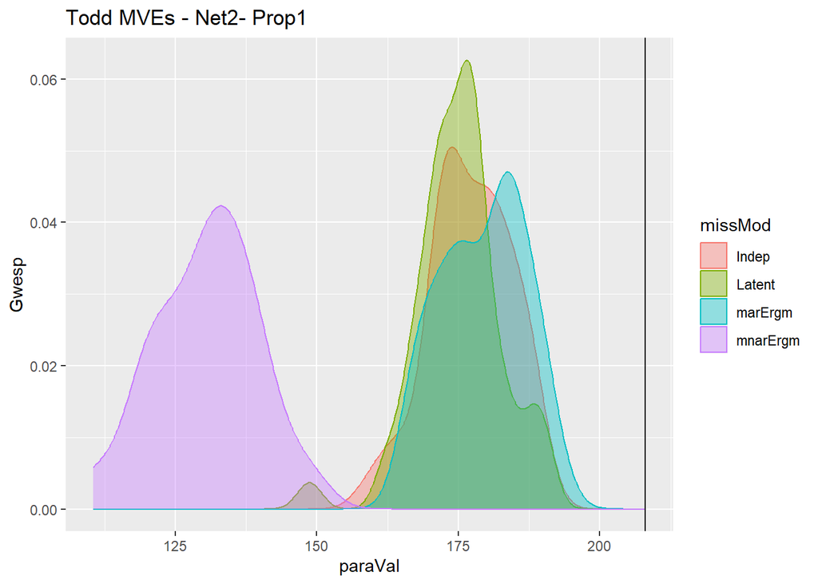

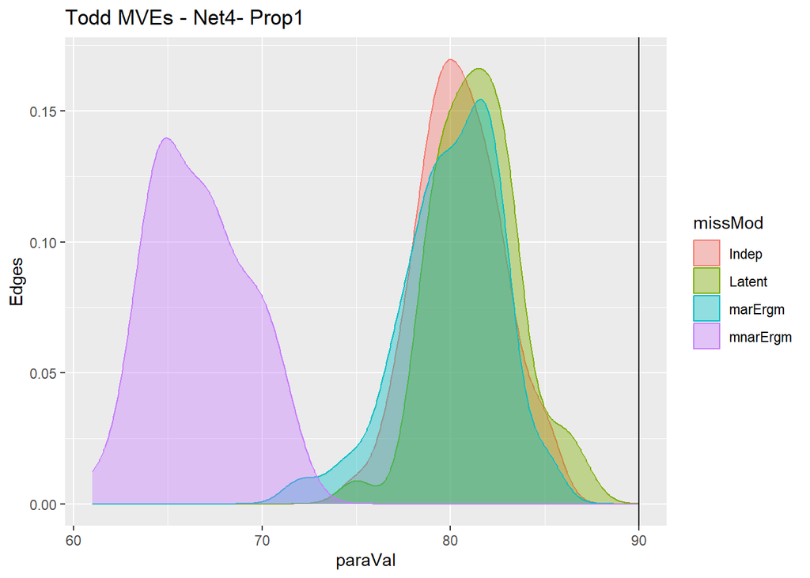

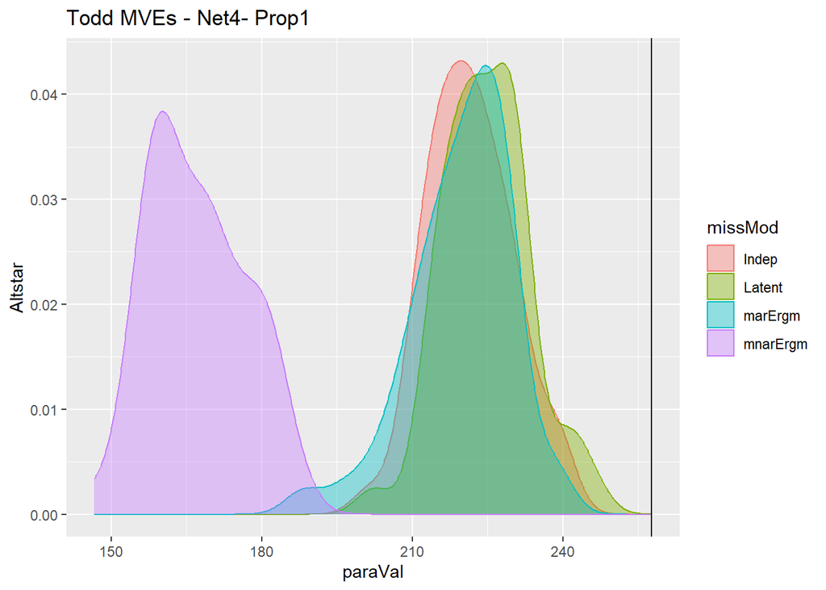

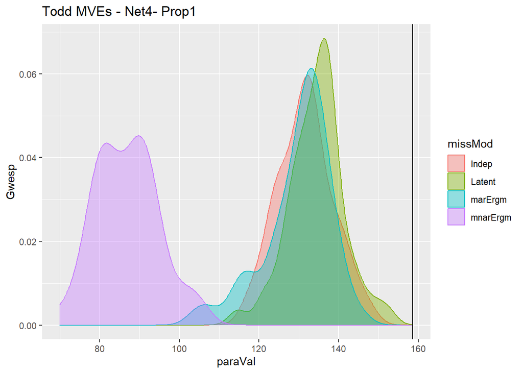

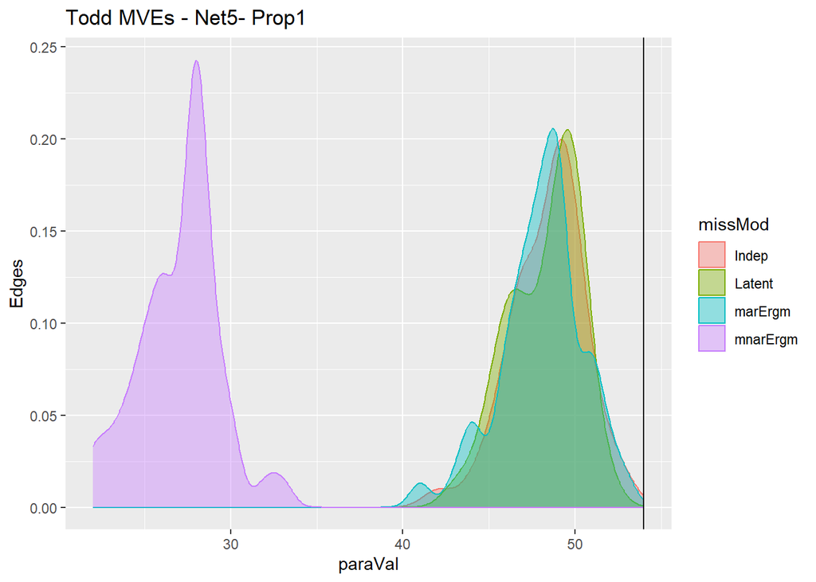

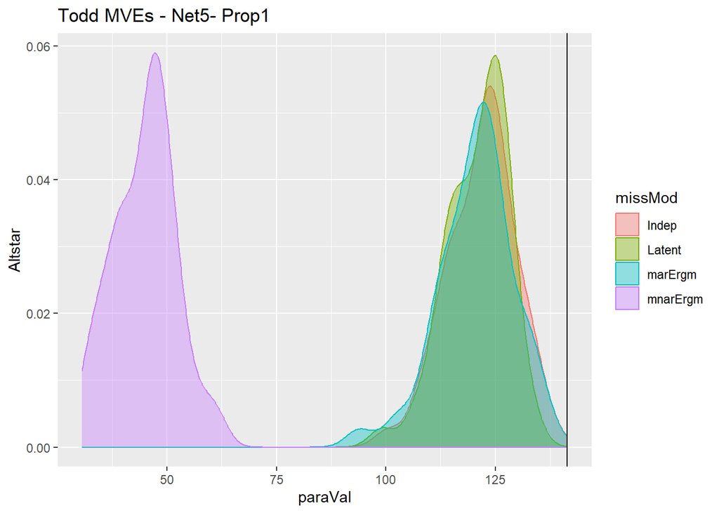

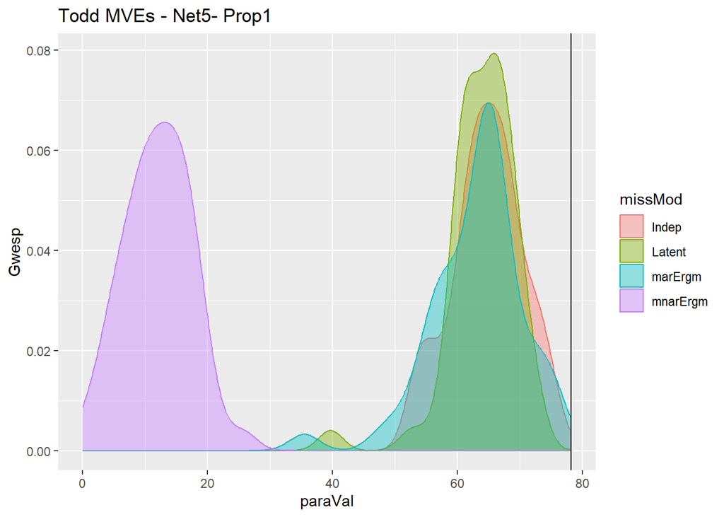

[3 more figures not shown]

```r
library(ggplot2)

# load the adjacency matrices for the respective datasets used
load(here("Data", "20231006_missNetsEnMasse.RData"))

# loading in the functions for missingness stuff
source(here("Scripts", "20230811_missNetFunctions.R"))

# TODO: choose a missingness proportion (1, 3.5 or 6)
chunkMissProp = 1

# now looping with a specific vector of applicable networks
# TODO: specify the UCINet networks for the chunk, these are networks with enough re-estimations
chunkNetworks = c(1, 2, 4, 5, 6)

# read files
# these are indep/mar/latent
load(here("Output", "20230814_simMissNets", paste("20231024_chosenMissNets_prop", chunkMissProp,".RData", sep = "")))

# with the list of missingness matrices, apply them to the true adjmat to deplete
# usingt he degrade adj function as a small shortcut
# a doozy of code line, but mostly due to the nested-list structure
# saving as Todd because we're calculating metrics

# for the whole compiled list of missingness matrices,
# go though all of the missingness models
# choose only the specified network,
# and for all the missingness matrices in them, degrade the specified true network (which is saved as a matrix)


# the master todd plot data
toddMvpPlotData = data.frame(paraVal = c(), paraName = c(), missMod = c(), net = c())

# loop start
for(chunkInd in 1:length(chunkNetworks)){

  # choose some network
  chosenNetInd = chunkNetworks[chunkInd]
  trueAdj = adjMatList[[chosenNetInd]]

  # degrade the adjlist with the simulated missingness matrices
  degradedAdjList = lapply(compiledMissNets, function(chosenMissMod){
    lapply(chosenMissMod[[chosenNetInd]], function(chosenMissAdj){
      degradeAdj(trueNet = trueAdj, missAdj = chosenMissAdj, missSave = 0)})})

  # turn all of them into networks
  degradedNetList = lapply(degradedAdjList, FUN = function(chosenMissMod){
    lapply(chosenMissMod, FUN = as.network, directed = FALSE)})

  # # then calculate metrics
  # degradedNetMetrics = lapply(degradedNetList, FUN = function(chosenMissMod){
  #   lapply(chosenMissMod, netMetrics)})


  # specify model
  chosenModel = "edges + altkstar(2, fixed = TRUE) + gwesp(decay = log(2), fixed = TRUE)"

  # specific branch for network 6
  if( chosenNetInd == 6 ){

    # specify the model
    chosenModel = "edges + altkstar(2, fixed = TRUE) + gwesp(decay = log(2), fixed = TRUE) +  nodecov('Age') +
      absdiff('Age') + nodecov('Arrests') + absdiff('Arrests') + nodecov('Convictions') + absdiff('Convictions') + nodematch('Prison') +
      nodematch('Birthplace')"

    # add in the covariates to all the network objects

    for(chosenMissMod in 1:length(degradedNetList)){
  degradedNetList[[chosenMissMod]] =  lapply(degradedNetList[[chosenMissMod]], FUN = function(chosenNet){
      set.vertex.attribute(x = chosenNet, attrname = "Age", value = londonGangsAtt$Age)
      set.vertex.attribute(x = chosenNet, attrname = "Arrests", value = londonGangsAtt$Arrests)
      set.vertex.attribute(x = chosenNet, attrname = "Birthplace", value = londonGangsAtt$Birthplace)
      set.vertex.attribute(x = chosenNet, attrname = "Convictions", value = londonGangsAtt$Convictions)
      set.vertex.attribute(x = chosenNet, attrname = "Prison", value = londonGangsAtt$Prison)

      })
    }

  }

  # and MVPs
  degradedMvpList = lapply(degradedNetList, FUN = function(chosenMissMod){
    lapply(chosenMissMod, FUN = meanValPar, model = chosenModel)})



  # miss models
  missMods = c("Indep", "marErgm", "Latent", "mnarErgm")

  for(chosenMissMod in 1:4){

    # chosen miss mod string
    chosenModString = missMods[chosenMissMod]

    # unlist
    toddUnlisted = unlist(degradedMvpList[[chosenMissMod]])

    uniqueParaNames = unique(names(toddUnlisted))

    # grab all the edges
    toddEdges = toddUnlisted[names(toddUnlisted) == uniqueParaNames[1]]

    # altstars
    toddAltstar = toddUnlisted[names(toddUnlisted) == uniqueParaNames[2]]

    # gwesps
    toddGwesp = toddUnlisted[names(toddUnlisted) == uniqueParaNames[3]]


    # using Todd (multiple miss mods)
    tempPlot = data.frame(paraVal = c(toddEdges, toddAltstar, toddGwesp),
                          paraName = c(rep("edges", length(toddEdges)), rep("Altstar", length(toddAltstar)), rep("gwesp", length(toddGwesp))),
                          missMod = rep(chosenModString, sum(length(toddEdges), length(toddAltstar), length(toddGwesp))),
                          net = rep(chosenNetInd, 150))

    # bind
    toddMvpPlotData = rbind(toddMvpPlotData, tempPlot)

  }

}

### Plotting section
# true Mvp list
trueMvpList = list()

for(chunkInd in 1:length(chunkNetworks)){

  # choose some network
  chosenNetInd = chunkNetworks[chunkInd]

  # find the true MVP for the given network
    # change the 'true' network depending on the chosen network index
  trueAdj = adjMatList[[chosenNetInd]]

  # turn into a network obj
  trueNet = as.network(trueAdj, directed = FALSE)

  if(chosenNetInd == 6){
    # add in the attributes for this network/model spec
      trueNet %v% 'Age' = londonGangsAtt$Age
      trueNet %v% 'Arrests' = londonGangsAtt$Arrests
      trueNet %v% 'Birthplace' = londonGangsAtt$Birthplace
      trueNet %v% 'Convictions' = londonGangsAtt$Convictions
      trueNet %v% 'Prison' = londonGangsAtt$Prison
  }


  # plot for the 'true' MVP, put in a list for later use
  chosenModel = "edges + altkstar(2, fixed = TRUE) + gwesp(decay = log(2), fixed = TRUE)"

  # since net 6 is different,
  if(chosenNetInd == 6){
    chosenModel = "edges + altkstar(2, fixed = TRUE) + gwesp(decay = log(2), fixed = TRUE) +  nodecov('Age') +
    absdiff('Age') + nodecov('Arrests') + absdiff('Arrests') + nodecov('Convictions') + absdiff('Convictions') + nodematch('Prison') +
    nodematch('Birthplace')"
  }

  chunkTrueMvp = meanValPar(net = trueNet,
                            model = chosenModel)

  trueMvpList[[chunkInd]] = chunkTrueMvp

  # wrangle specific parts of the data
  toddMvpPlotSubset = toddMvpPlotData %>%
    filter(paraName == "edges" & net == chosenNetInd)

  print(ggplot(toddMvpPlotSubset, aes(x = paraVal, colour = missMod, fill = missMod)) +
   # geom_histogram(alpha = 0.4, position = "identity", binwidth = 1) +
    geom_density(alpha = 0.4) +
    geom_vline(xintercept = trueMvpList[[chunkInd]][1]) +
    ylab(paste("Edges")) +
    ggtitle(label = paste("Todd MVEs - Net", chosenNetInd, "- Prop", chunkMissProp, sep = "")))

  toddMvpPlotSubset = toddMvpPlotData %>%
    filter(paraName == "Altstar" & net == chosenNetInd)

  print(ggplot(toddMvpPlotSubset, aes(x = paraVal, colour = missMod, fill = missMod)) +
   # geom_histogram(alpha = 0.4, position = "identity", binwidth = 1) +
    geom_density(alpha = 0.4) +
    geom_vline(xintercept = trueMvpList[[chunkInd]][2]) +
    ylab(paste("Altstar")) +
    ggtitle(label = paste("Todd MVEs - Net", chosenNetInd, "- Prop", chunkMissProp, sep = "")))

  toddMvpPlotSubset = toddMvpPlotData %>%
    filter(paraName == "gwesp" & net == chosenNetInd)

  print(ggplot(toddMvpPlotSubset, aes(x = paraVal, colour = missMod, fill = missMod)) +
   # geom_histogram(alpha = 0.4, position = "identity", binwidth = 1) +
    geom_density(alpha = 0.4) +
    geom_vline(xintercept = trueMvpList[[chunkInd]][3]) +
    ylab(paste("Gwesp")) +
    ggtitle(label = paste("Todd MVEs - Net", chosenNetInd, "- Prop", chunkMissProp, sep = "")))


}
```

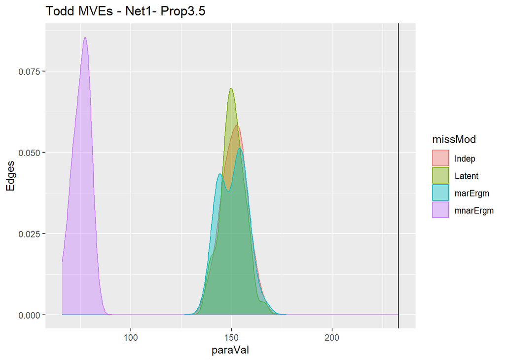

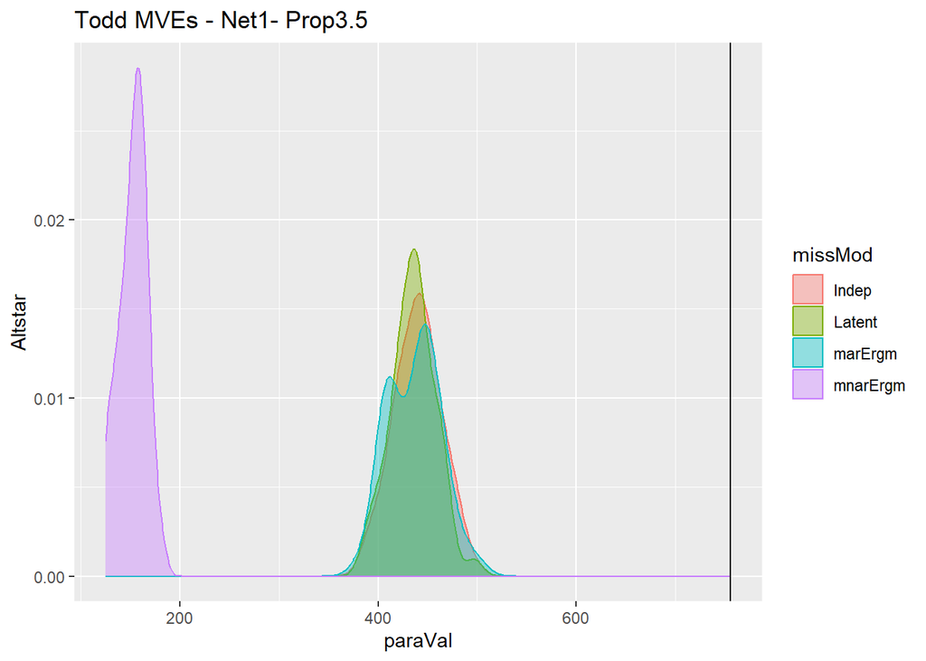

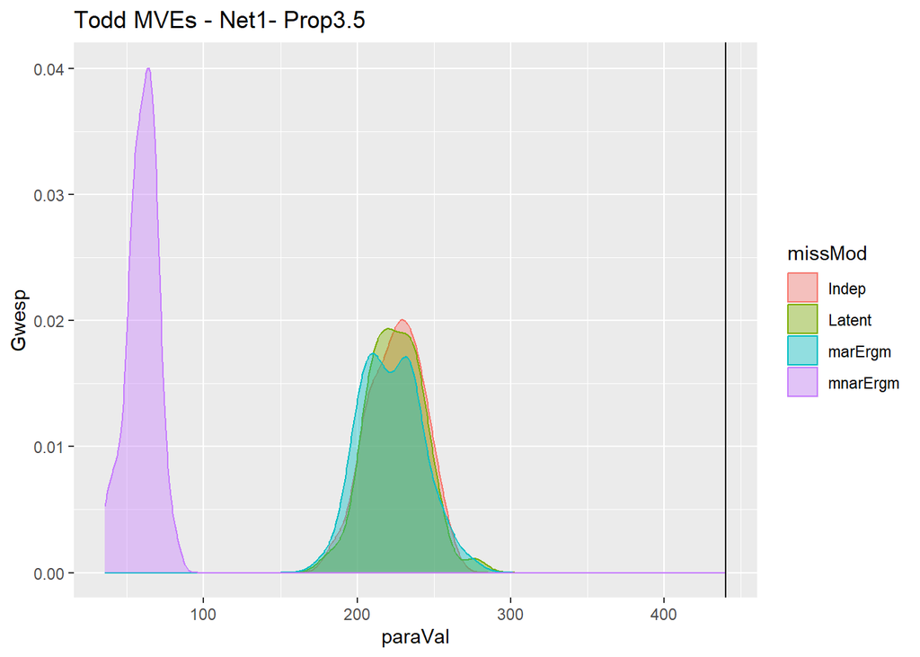

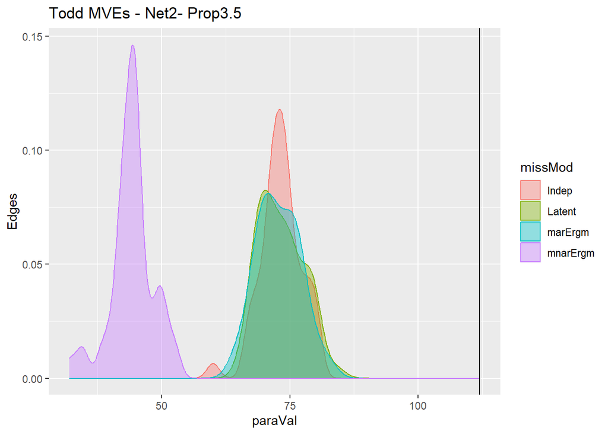

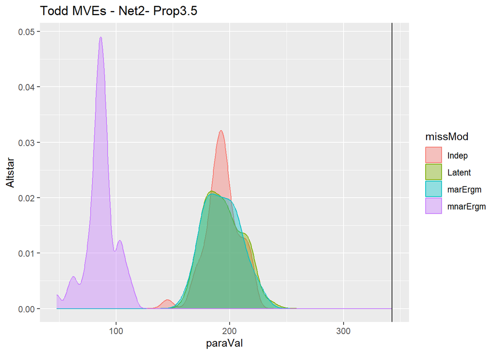

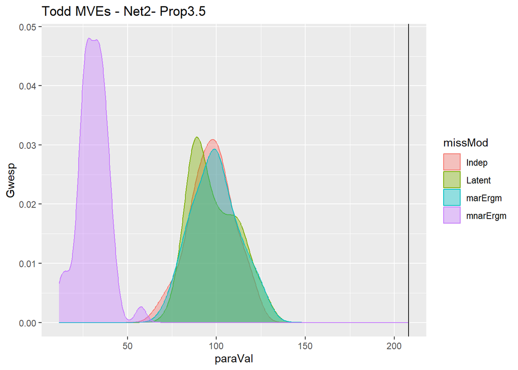

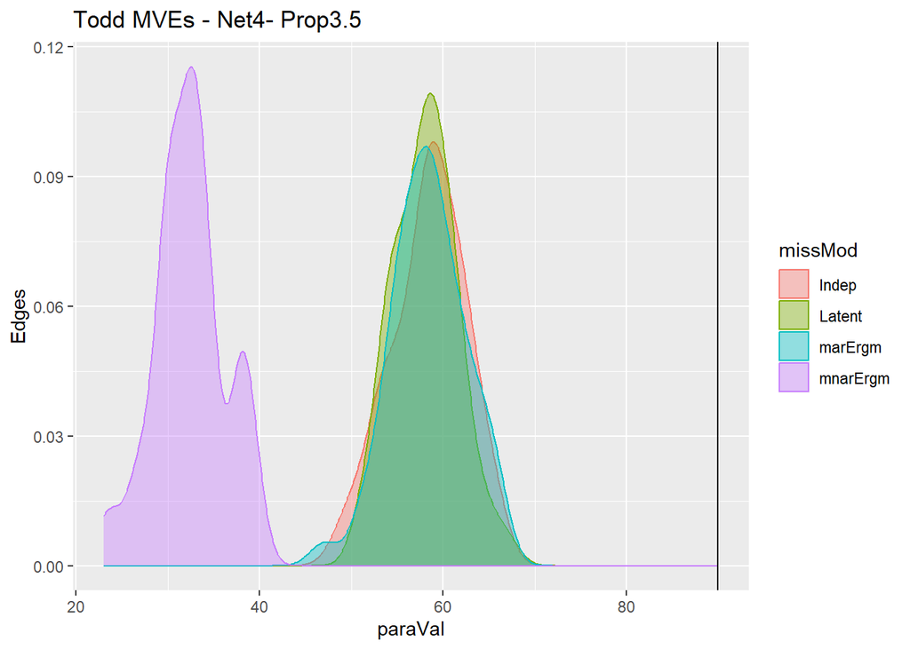

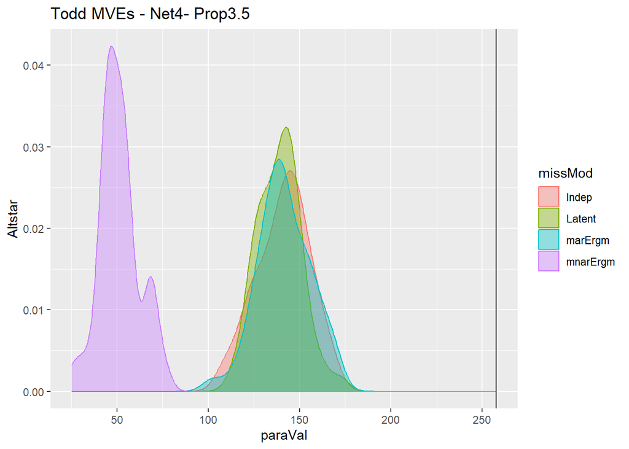

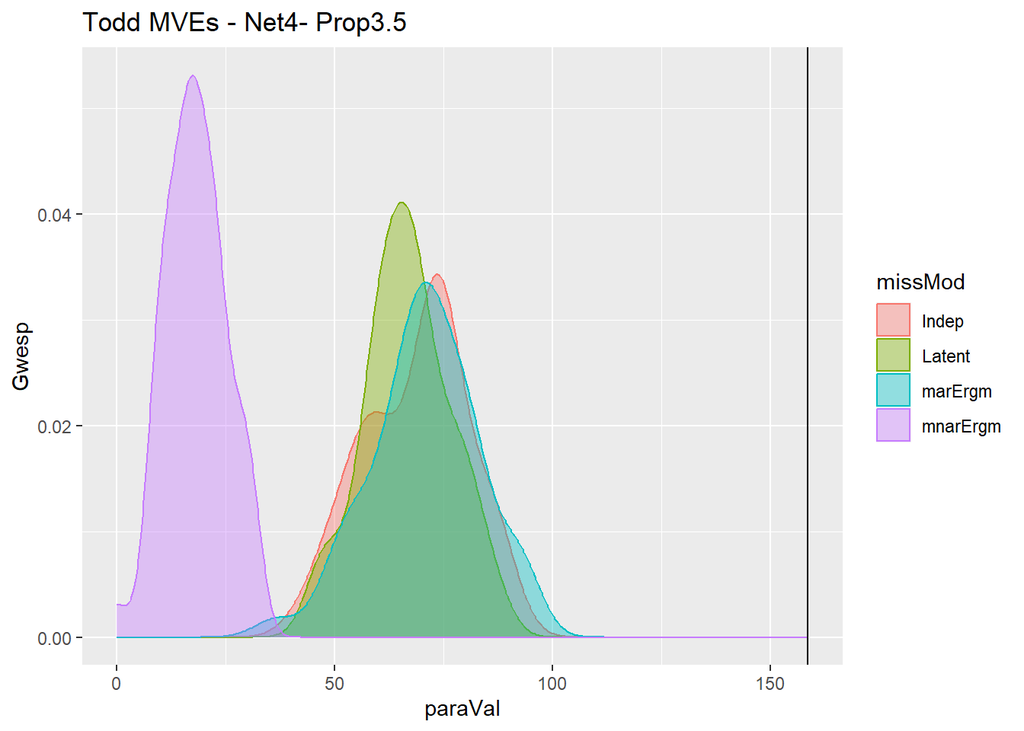

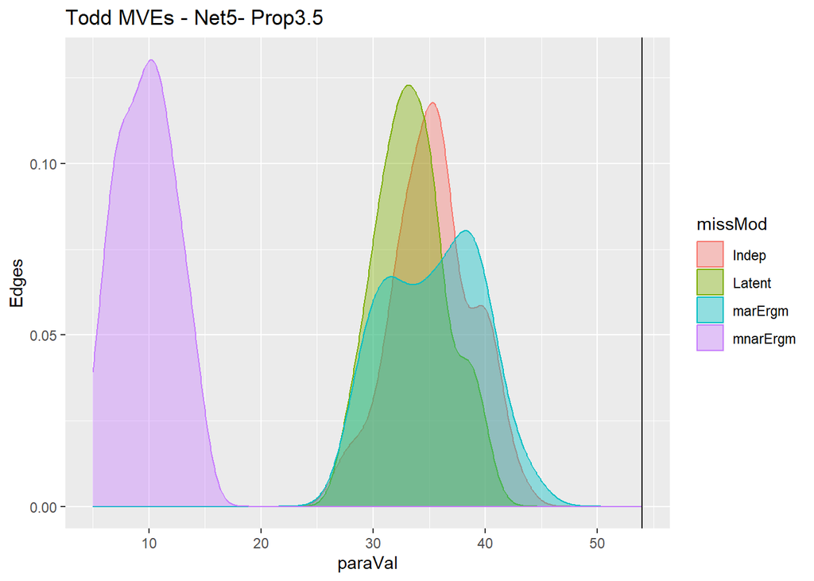

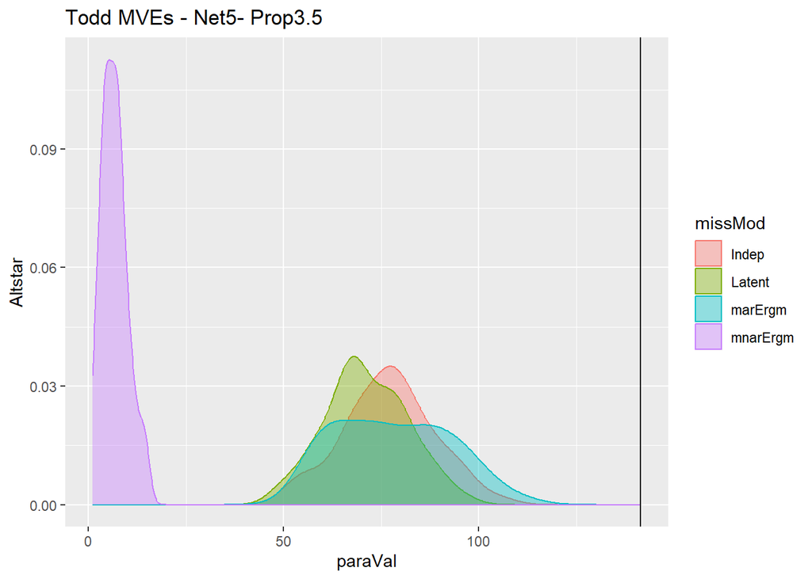

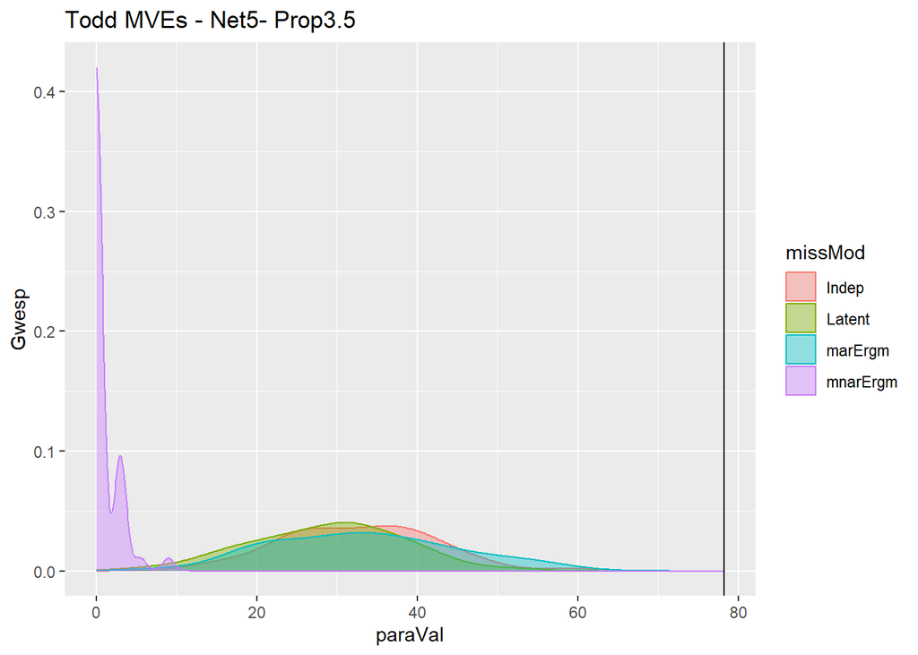

[3 more figures not shown]

```r
# TODO: choose a missingness proportion (1, 3.5 or 6)
chunkMissProp = 3
chunkMissPropFloat = 3.5

# now looping with a specific vector of applicable networks
# TODO: specify the UCINet networks for the chunk, these are networks with enough re-estimations
chunkNetworks = c(1, 2, 4, 5, 6)

# read files
# these are indep/mar/latent
load(here("Output", "20230814_simMissNets", paste("20231024_chosenMissNets_prop", chunkMissPropFloat,".RData", sep = "")))

# with the list of missingness matrices, apply them to the true adjmat to deplete
# usingt he degrade adj function as a small shortcut
# a doozy of code line, but mostly due to the nested-list structure
# saving as Todd because we're calculating metrics

# for the whole compiled list of missingness matrices,
# go though all of the missingness models
# choose only the specified network,
# and for all the missingness matrices in them, degrade the specified true network (which is saved as a matrix)


# the master todd plot data
toddMvpPlotData = data.frame(paraVal = c(), paraName = c(), missMod = c(), net = c())

# loop start
for(chunkInd in 1:length(chunkNetworks)){

  # choose some network
  chosenNetInd = chunkNetworks[chunkInd]
  trueAdj = adjMatList[[chosenNetInd]]

  # degrade the adjlist with the simulated missingness matrices
  degradedAdjList = lapply(compiledMissNets, function(chosenMissMod){
    lapply(chosenMissMod[[chosenNetInd]], function(chosenMissAdj){
      degradeAdj(trueNet = trueAdj, missAdj = chosenMissAdj, missSave = 0)})})

  # turn all of them into networks
  degradedNetList = lapply(degradedAdjList, FUN = function(chosenMissMod){
    lapply(chosenMissMod, FUN = as.network, directed = FALSE)})

  # # then calculate metrics
  # degradedNetMetrics = lapply(degradedNetList, FUN = function(chosenMissMod){
  #   lapply(chosenMissMod, netMetrics)})


  # specify model
  chosenModel = "edges + altkstar(2, fixed = TRUE) + gwesp(decay = log(2), fixed = TRUE)"

  # specific branch for network 6
  if( chosenNetInd == 6 ){

    # specify the model
    chosenModel = "edges + altkstar(2, fixed = TRUE) + gwesp(decay = log(2), fixed = TRUE) +  nodecov('Age') +
      absdiff('Age') + nodecov('Arrests') + absdiff('Arrests') + nodecov('Convictions') + absdiff('Convictions') + nodematch('Prison') +
      nodematch('Birthplace')"

    # add in the covariates to all the network objects

    for(chosenMissMod in 1:length(degradedNetList)){
  degradedNetList[[chosenMissMod]] =  lapply(degradedNetList[[chosenMissMod]], FUN = function(chosenNet){
      set.vertex.attribute(x = chosenNet, attrname = "Age", value = londonGangsAtt$Age)
      set.vertex.attribute(x = chosenNet, attrname = "Arrests", value = londonGangsAtt$Arrests)
      set.vertex.attribute(x = chosenNet, attrname = "Birthplace", value = londonGangsAtt$Birthplace)
      set.vertex.attribute(x = chosenNet, attrname = "Convictions", value = londonGangsAtt$Convictions)
      set.vertex.attribute(x = chosenNet, attrname = "Prison", value = londonGangsAtt$Prison)

      })
    }

  }

  # and MVPs
  degradedMvpList = lapply(degradedNetList, FUN = function(chosenMissMod){
    lapply(chosenMissMod, FUN = meanValPar, model = chosenModel)})



  # miss models
  missMods = c("Indep", "marErgm", "Latent", "mnarErgm")

  for(chosenMissMod in 1:4){

    # chosen miss mod string
    chosenModString = missMods[chosenMissMod]

    # unlist
    toddUnlisted = unlist(degradedMvpList[[chosenMissMod]])

    uniqueParaNames = unique(names(toddUnlisted))

    # grab all the edges
    toddEdges = toddUnlisted[names(toddUnlisted) == uniqueParaNames[1]]

    # altstars
    toddAltstar = toddUnlisted[names(toddUnlisted) == uniqueParaNames[2]]

    # gwesps
    toddGwesp = toddUnlisted[names(toddUnlisted) == uniqueParaNames[3]]


    # using Todd (multiple miss mods)
    tempPlot = data.frame(paraVal = c(toddEdges, toddAltstar, toddGwesp),
                          paraName = c(rep("edges", length(toddEdges)), rep("Altstar", length(toddAltstar)), rep("gwesp", length(toddGwesp))),
                          missMod = rep(chosenModString, sum(length(toddEdges), length(toddAltstar), length(toddGwesp))),
                          net = rep(chosenNetInd, 150))

    # bind
    toddMvpPlotData = rbind(toddMvpPlotData, tempPlot)

  }

}

### Plotting section
# true Mvp list
trueMvpList = list()

for(chunkInd in 1:length(chunkNetworks)){

  # choose some network
  chosenNetInd = chunkNetworks[chunkInd]

  # find the true MVP for the given network
    # change the 'true' network depending on the chosen network index
  trueAdj = adjMatList[[chosenNetInd]]

  # turn into a network obj
  trueNet = as.network(trueAdj, directed = FALSE)

  if(chosenNetInd == 6){
    # add in the attributes for this network/model spec
      trueNet %v% 'Age' = londonGangsAtt$Age
      trueNet %v% 'Arrests' = londonGangsAtt$Arrests
      trueNet %v% 'Birthplace' = londonGangsAtt$Birthplace
      trueNet %v% 'Convictions' = londonGangsAtt$Convictions
      trueNet %v% 'Prison' = londonGangsAtt$Prison
  }


  # plot for the 'true' MVP, put in a list for later use
  chosenModel = "edges + altkstar(2, fixed = TRUE) + gwesp(decay = log(2), fixed = TRUE)"

  # since net 6 is different,
  if(chosenNetInd == 6){
    chosenModel = "edges + altkstar(2, fixed = TRUE) + gwesp(decay = log(2), fixed = TRUE) +  nodecov('Age') +
    absdiff('Age') + nodecov('Arrests') + absdiff('Arrests') + nodecov('Convictions') + absdiff('Convictions') + nodematch('Prison') +
    nodematch('Birthplace')"
  }

  chunkTrueMvp = meanValPar(net = trueNet,
                            model = chosenModel)

  trueMvpList[[chunkInd]] = chunkTrueMvp

  # wrangle specific parts of the data
  toddMvpPlotSubset = toddMvpPlotData %>%
    filter(paraName == "edges" & net == chosenNetInd)

  print(ggplot(toddMvpPlotSubset, aes(x = paraVal, colour = missMod, fill = missMod)) +
   # geom_histogram(alpha = 0.4, position = "identity", binwidth = 1) +
    geom_density(alpha = 0.4) +
    geom_vline(xintercept = trueMvpList[[chunkInd]][1]) +
    ylab(paste("Edges")) +
    ggtitle(label = paste("Todd MVEs - Net", chosenNetInd, "- Prop", chunkMissPropFloat, sep = "")))

  toddMvpPlotSubset = toddMvpPlotData %>%
    filter(paraName == "Altstar" & net == chosenNetInd)

  print(ggplot(toddMvpPlotSubset, aes(x = paraVal, colour = missMod, fill = missMod)) +
   # geom_histogram(alpha = 0.4, position = "identity", binwidth = 1) +
    geom_density(alpha = 0.4) +
    geom_vline(xintercept = trueMvpList[[chunkInd]][2]) +
    ylab(paste("Altstar")) +
    ggtitle(label = paste("Todd MVEs - Net", chosenNetInd, "- Prop", chunkMissPropFloat, sep = "")))

  toddMvpPlotSubset = toddMvpPlotData %>%
    filter(paraName == "gwesp" & net == chosenNetInd)

  print(ggplot(toddMvpPlotSubset, aes(x = paraVal, colour = missMod, fill = missMod)) +
   # geom_histogram(alpha = 0.4, position = "identity", binwidth = 1) +
    geom_density(alpha = 0.4) +
    geom_vline(xintercept = trueMvpList[[chunkInd]][3]) +
    ylab(paste("Gwesp")) +
    ggtitle(label = paste("Todd MVEs - Net", chosenNetInd, "- Prop", chunkMissPropFloat, sep = "")))


}
```